# Week 3 exercises

```r
# set working directory and read in previously created txt file
setwd("/Users/nygrpetr/Desktop/iods/iods_petra/")
alc_data <- read.csv("data/alc_data.csv")
print(colnames(alc_data))
```

```
##  [1] "school"     "sex"        "age"        "address"    "famsize"
##  [6] "Pstatus"    "Medu"       "Fedu"       "Mjob"       "Fjob"
## [11] "reason"     "guardian"   "traveltime" "studytime"  "schoolsup"
## [16] "famsup"     "activities" "nursery"    "higher"     "internet"
## [21] "romantic"   "famrel"     "freetime"   "goout"      "Dalc"
## [26] "Walc"       "health"     "failures"   "paid"       "absences"
## [31] "G1"         "G2"         "G3"         "alc_use"    "high_use"
```

The dataset we are using includes data on students’ achievement in secondary education of two schools in Portugal. The variables include student grades, demographic such as mother and father education, social and school related features. The two datasets concern different subjects: Mathematics (mat) and Portuguese language (por). We have added a column alc_use which is the average of weekday and weekend alcohol use.

Here, we aim to study the relationships between alcohol use and the variables in the data. The purpose of your analysis is to study the relationships between high/low alcohol consumption and some of the other variables in the data. To do this, choose 4 interesting variables in the data and for each of them, present your personal hypothesis about their relationships with alcohol consumption.

I chose to study 4 variables: sex, Pstatus, Medu (mother’s education) and health. I hypothesize that 1) Male sex will correlate with higher alcohol use 2) Pstatus - students with parents who live together would use less alcohol 3) Students whose mothers are highly educated would use less alcohol 4) Students with better health status use less alchohol

Next, we will explore the distributions of the previously mentioned variables and their association with alcohol use

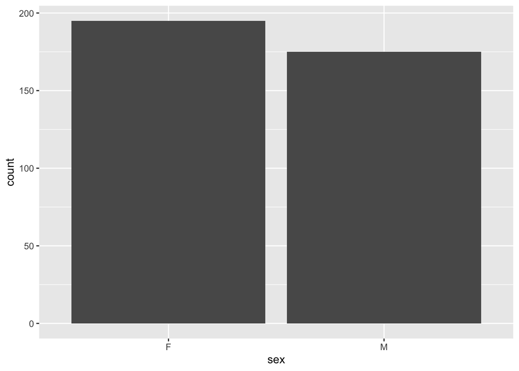

```r
library(ggplot2)
library(tidyr)
library(dplyr)
ggplot(alc_data, aes(sex)) + geom_bar()
```

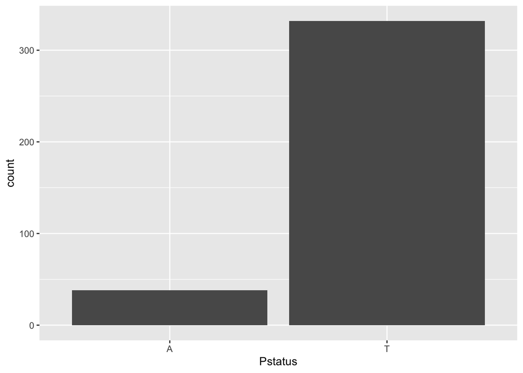

```r
ggplot(alc_data, aes(Pstatus)) + geom_bar()
```

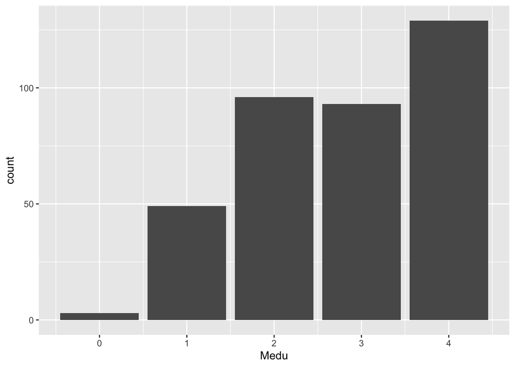

```r
ggplot(alc_data, aes(Medu)) + geom_bar()
```

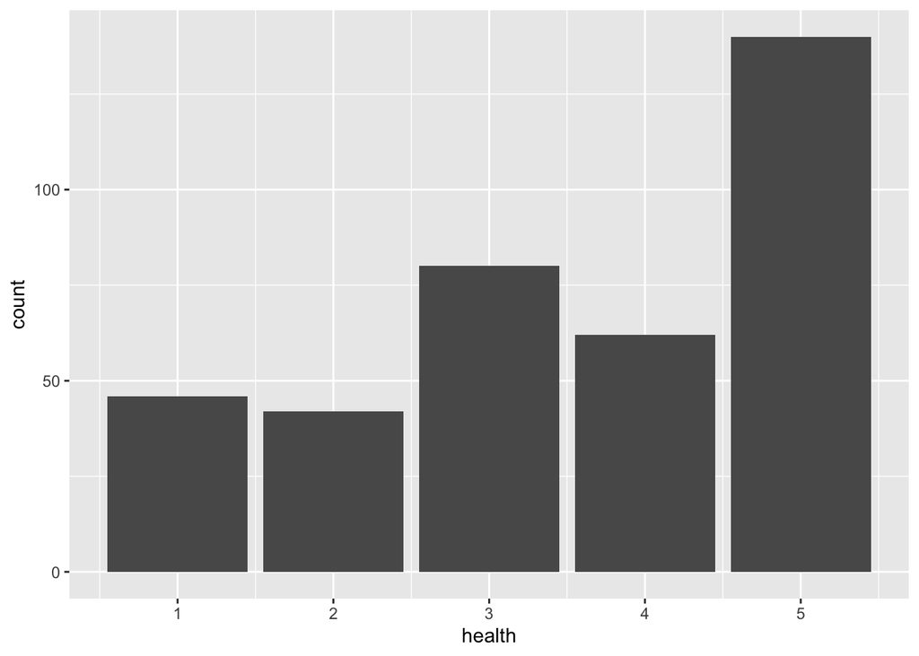

```r
ggplot(alc_data, aes(health)) + geom_bar()
```

In the dataset, there are more female students than male, most of the students’ parents live together, more students have highly educated mothers than lowly educated, and more students have the highest degree of health than the lowest degree

```r
#Check what proprotions of students in each category (sex: M/F, Pstatus: T/A, Medu: high values to low values, health: low val to high) belong to high alcohol use group
alc_data %>% group_by(sex, high_use) %>% summarise(count = n()) %>% mutate(prop = count / sum(count))
```

[output not shown]

```
## # A tibble: 4 × 4
## # Groups:   sex [2]
##   sex   high_use count  prop
##   <chr> <lgl>    <int> <dbl>
## 1 F     FALSE      154 0.790
## 2 F     TRUE        41 0.210
## 3 M     FALSE      105 0.6
## 4 M     TRUE        70 0.4
```

```r
alc_data %>% group_by(Pstatus, high_use) %>% summarise(count = n()) %>% mutate(prop = count / sum(count))
```

```
## # A tibble: 4 × 4
## # Groups:   Pstatus [2]
##   Pstatus high_use count  prop
##   <chr>   <lgl>    <int> <dbl>
## 1 A       FALSE       26 0.684
## 2 A       TRUE        12 0.316
## 3 T       FALSE      233 0.702
## 4 T       TRUE        99 0.298
```

```r
alc_data %>% group_by(Medu, high_use) %>% summarise(count = n()) %>% mutate(prop = count / sum(count))
```

```
## # A tibble: 10 × 4
## # Groups:   Medu [5]
##     Medu high_use count  prop
##    <int> <lgl>    <int> <dbl>
##  1     0 FALSE        1 0.333
##  2     0 TRUE         2 0.667
##  3     1 FALSE       31 0.633
##  4     1 TRUE        18 0.367
##  5     2 FALSE       78 0.812
##  6     2 TRUE        18 0.188
##  7     3 FALSE       57 0.613
##  8     3 TRUE        36 0.387
##  9     4 FALSE       92 0.713
## 10     4 TRUE        37 0.287
```

```r
alc_data %>% group_by(health, high_use) %>% summarise(count = n()) %>% mutate(prop = count / sum(count))
```

```
## # A tibble: 10 × 4
## # Groups:   health [5]
##    health high_use count  prop
##     <int> <lgl>    <int> <dbl>
##  1      1 FALSE       35 0.761
##  2      1 TRUE        11 0.239
##  3      2 FALSE       28 0.667
##  4      2 TRUE        14 0.333
##  5      3 FALSE       61 0.762
##  6      3 TRUE        19 0.238
##  7      4 FALSE       45 0.726
##  8      4 TRUE        17 0.274
##  9      5 FALSE       90 0.643
## 10      5 TRUE        50 0.357
```

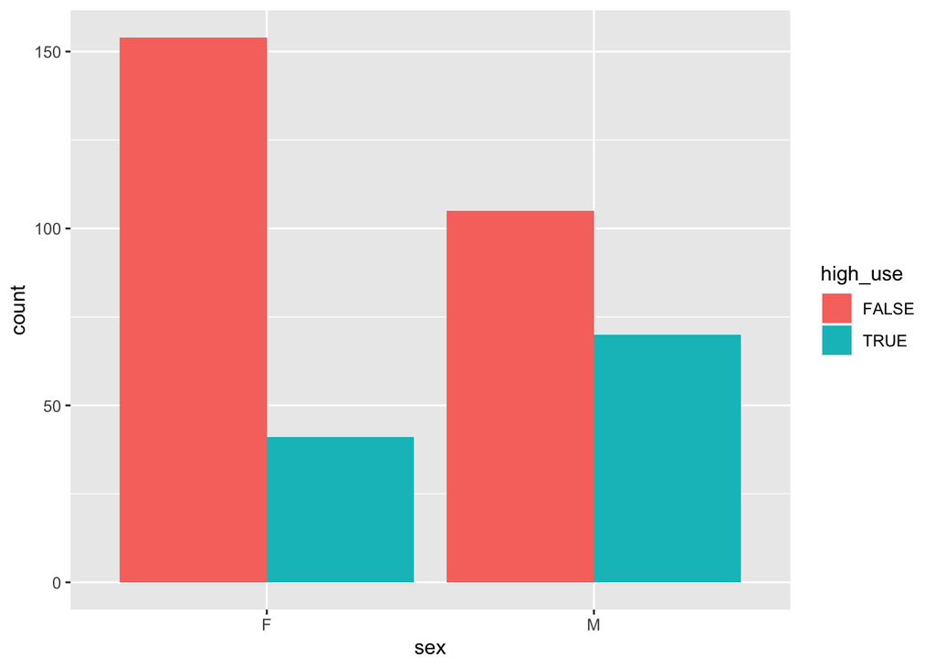

```r
ggplot(data = alc_data, aes(x = sex, fill = high_use)) +
  geom_bar(position = "dodge")
```

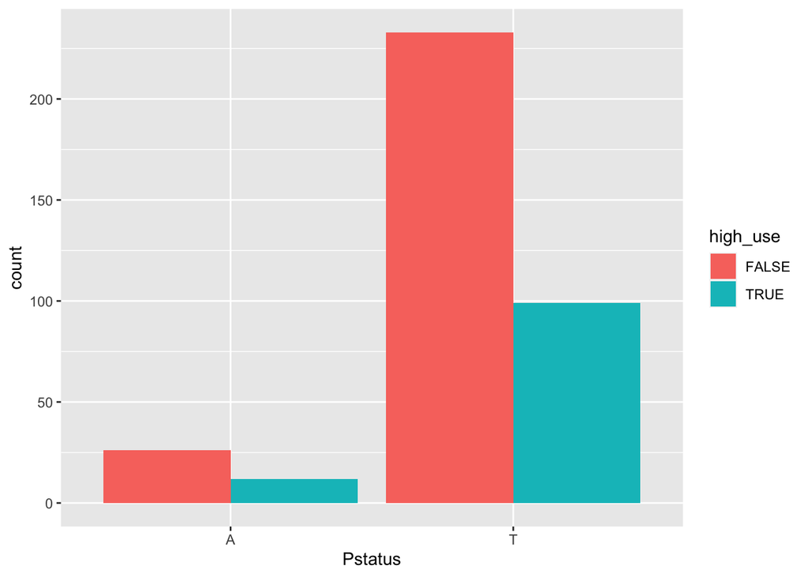

```r
ggplot(data = alc_data, aes(x = Pstatus, fill = high_use)) +
  geom_bar(position = "dodge")
```

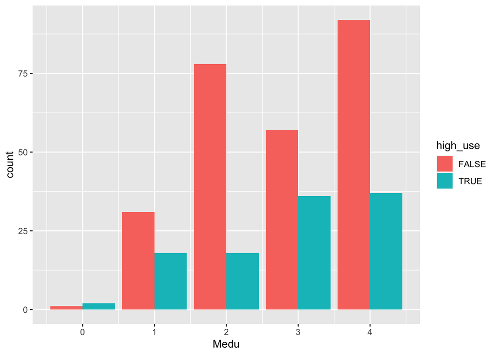

```r
ggplot(data = alc_data, aes(x = Medu, fill = high_use)) +
  geom_bar(position = "dodge")
```

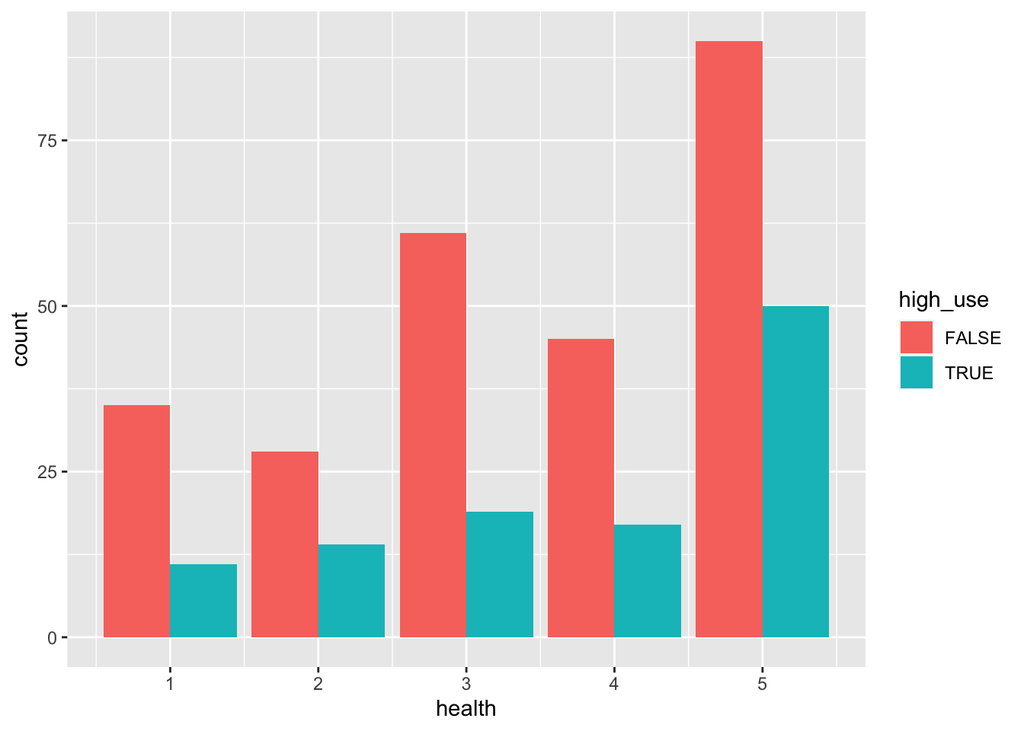

```r
ggplot(data = alc_data, aes(x = health, fill = high_use)) +
  geom_bar(position = "dodge")
```

Next, we will run a regression model to test the relationships between the variables and alcohol use. We will process factor variables and categorical variables in a different way.

```r
#Turn Medu and health into factors to enable them to be used in the model
alc_data$Medu <- factor(alc_data$Medu)
alc_data$health<- factor(alc_data$health)

#Run regression model
my.mod <- glm(high_use ~ sex + Pstatus + Medu + health, data = alc_data, family = "binomial")

summary(my.mod)
```

```
##
## Call:
## glm(formula = high_use ~ sex + Pstatus + Medu + health, family = "binomial",
##     data = alc_data)
##
## Coefficients:
##             Estimate Std. Error z value Pr(>|z|)
## (Intercept)  0.03050    1.35266   0.023  0.98201
## sexM         0.92338    0.24456   3.776  0.00016 ***
## PstatusT    -0.09829    0.39260  -0.250  0.80232
## Medu1       -1.12776    1.29505  -0.871  0.38385
## Medu2       -2.16404    1.28249  -1.687  0.09153 .
## Medu3       -1.16803    1.27388  -0.917  0.35919
## Medu4       -1.69835    1.27132  -1.336  0.18158
## health2      0.55552    0.50095   1.109  0.26745
## health3      0.02365    0.45133   0.052  0.95821
## health4      0.28251    0.46379   0.609  0.54243
## health5      0.44817    0.40569   1.105  0.26929
## ---
## Signif. codes:  0 '***' 0.001 '**' 0.01 '*' 0.05 '.' 0.1 ' ' 1
##
## (Dispersion parameter for binomial family taken to be 1)
##
##     Null deviance: 452.04  on 369  degrees of freedom
## Residual deviance: 420.13  on 359  degrees of freedom
## AIC: 442.13
##
## Number of Fisher Scoring iterations: 4
```

```r
#Compute odds ratios and confidence intervals, print the results
OR <- coef(my.mod) %>% exp
CI <- confint(my.mod) %>% exp
cbind(OR, CI)
```

```
##                    OR       2.5 %    97.5 %
## (Intercept) 1.0309650 0.076881229 25.754772
## sexM        2.5177759 1.566506913  4.093497
## PstatusT    0.9063878 0.427092627  2.013112
## Medu1       0.3237572 0.013860043  3.858076
## Medu2       0.1148602 0.004990072  1.336025
## Medu3       0.3109786 0.013654668  3.562161
## Medu4       0.1829843 0.008056463  2.084139
## health2     1.7428548 0.655437479  4.730204
## health3     1.0239323 0.426979687  2.535839
## health4     1.3264582 0.538881788  3.360685
## health5     1.5654372 0.722581102  3.586186
```

Next we will use only the variable “sex” which was the only significant one to fit a new model, and use it to predict probabilities of high use tehn compare it to the actual values to investigate the predictive power of the model.

```r
new.mod <- glm(high_use ~ sex, data = alc_data, family = "binomial")
probabilities <- predict(new.mod, type = "response")

#Add column for probabilities, use it to make predictions of high use, and get teh last 10 values
alc_data <- mutate(alc_data, probability = probabilities)
alc_data <- mutate(alc_data, prediction = probability > 0.5)
select(alc_data, sex, high_use, probability, prediction) %>% tail(10)
```

```
##     sex high_use probability prediction
## 361   M    FALSE   0.4000000      FALSE
## 362   M    FALSE   0.4000000      FALSE
## 363   M     TRUE   0.4000000      FALSE
## 364   F    FALSE   0.2102564      FALSE
## 365   F    FALSE   0.2102564      FALSE
## 366   F    FALSE   0.2102564      FALSE
## 367   F    FALSE   0.2102564      FALSE
## 368   F    FALSE   0.2102564      FALSE
## 369   M     TRUE   0.4000000      FALSE
## 370   M     TRUE   0.4000000      FALSE
```

```r
#Make a table
table(high_use = alc_data$high_use, prediction = alc_data$prediction)
```

```
##         prediction
## high_use FALSE
##    FALSE   259
##    TRUE    111
```

```r
prop.table(table(high_use = alc_data$high_use, prediction = alc_data$prediction)) * 100
```

```
##         prediction
## high_use FALSE
##    FALSE    70
##    TRUE     30
```

I would say the the model is good but not great for this data, 259 observations with FALSE for high use corresponded to the predictions of FALSE, but the model misstakenly predicted FALSE for 111 high use values which were actually true, so I would not use this model as the predictive power is subpar.